# Assumption Validation

### A. Conventionality of Linear Model

The linear model graph is assumed to be a conventional representation of temporal intervals, that students will find relatively easy to understand and therefore facilitate answering questions.

**1. In the control condition, the mean score for linear model task should be greater than for the triangular model task, and the response times should be shorter.**

```
      median         mean      SE.mean CI.mean.0.95          var      std.dev     coef.var     skewness     skew.2SE     kurtosis
   8.5500000    8.6155738    0.2716270    0.5433349    4.5006551    2.1214747    0.2462372    0.2005098    0.3273417    0.2575769
    kurt.2SE   normtest.W   normtest.p
   0.2132834    0.9882055    0.8239503
      median         mean      SE.mean CI.mean.0.95          var      std.dev     coef.var     skewness     skew.2SE     kurtosis
 11.42000000  11.15180328   0.45468505   0.90950552  12.61104836   3.55120379   0.31844211   0.03696643   0.06034944  -0.20232159
    kurt.2SE   normtest.W   normtest.p
 -0.16752993   0.98538492   0.68007541

    Paired t-test

data:  w.0$LM_T_M and w.0$TM_T_M
t = -6.9248, df = 60, p-value = 3.361e-09
alternative hypothesis: true difference in means is not equal to 0
95 percent confidence interval:
 -3.268845 -1.803614
sample estimates:
mean of the differences
               -2.53623

[1] 0.666
      median         mean      SE.mean CI.mean.0.95          var      std.dev     coef.var     skewness     skew.2SE     kurtosis
11.000000000 10.983606557  0.297982105  0.596052956  5.416393443  2.327314642  0.211889841 -0.909060012 -1.484083130  1.829432722
    kurt.2SE   normtest.W   normtest.p
 1.514839482  0.931712630  0.002129683
       median          mean       SE.mean  CI.mean.0.95           var       std.dev      coef.var      skewness      skew.2SE
 6.0000000000  6.9016393443  0.5772106083  1.1545931227 20.3234972678  4.5081589666  0.6532011804  0.0729808749  0.1191447031
     kurtosis      kurt.2SE    normtest.W    normtest.p
-1.4749119158 -1.2212828465  0.9136025871  0.0003816004

    Paired t-test

data:  w.0$linear_score and w.0$triangular_score
t = 7.0685, df = 60, p-value = 1.912e-09
alternative hypothesis: true difference in means is not equal to 0
95 percent confidence interval:
 2.926815 5.237119
sample estimates:
mean of the differences
               4.081967

[1] 0.674
```

For the entire experiment (across both graph order levels)…

- the response time for the Linear Model Task (M = 8.62 minutes, SD = 2.12) was significantly shorter than for the Triangular Model Task (M = 11.15 minutes, SD = 3.55), t(60) = -6.92, p < 0.01; a very large effect r = 0.67.
- the comprehension scores (R= 0-15) for the Linear Model task (M = 10.98, SD = 2.33) were significantly greater than for the Triangular Model Task (M = 6.90, SD = 4.51), t(60) = 7.07, p < 0.01; a very large effect r = 0.67.  
  **Therefore, this assumption #1 is confirmed.**

**2. The mean response time for the linear model task should not differ between experimental (scaffold) groups.**

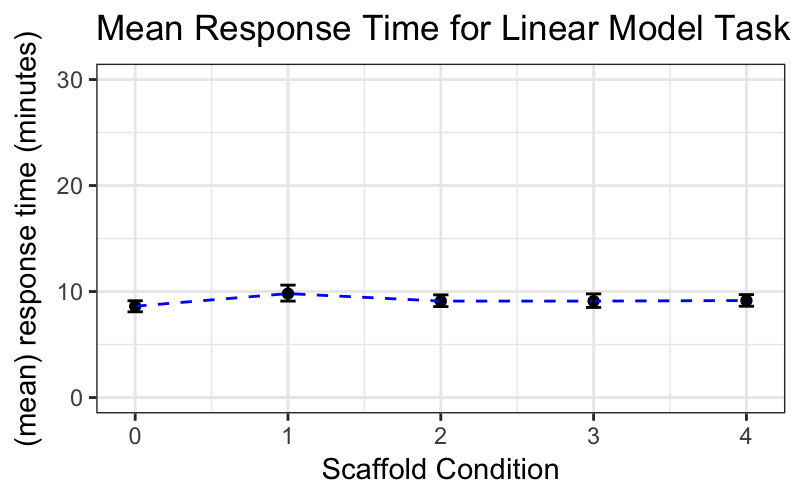

```
participantData$condition: 0
     nbr.val     nbr.null       nbr.na          min          max        range          sum       median         mean      SE.mean
  61.0000000    0.0000000    0.0000000    3.9200000   15.0500000   11.1300000  525.5500000    8.5500000    8.6155738    0.2716270
CI.mean.0.95          var      std.dev     coef.var
   0.5433349    4.5006551    2.1214747    0.2462372
--------------------------------------------------------------------------------------------------------
participantData$condition: 1
     nbr.val     nbr.null       nbr.na          min          max        range          sum       median         mean      SE.mean
  60.0000000    0.0000000    0.0000000    4.6300000   22.0400000   17.4100000  588.2500000    9.3750000    9.8041667    0.3814908
CI.mean.0.95          var      std.dev     coef.var
   0.7633613    8.7321129    2.9550149    0.3014040
--------------------------------------------------------------------------------------------------------
participantData$condition: 2
     nbr.val     nbr.null       nbr.na          min          max        range          sum       median         mean      SE.mean
  66.0000000    0.0000000    0.0000000    5.0900000   15.2800000   10.1900000  600.5100000    8.9400000    9.0986364    0.2824377
CI.mean.0.95          var      std.dev     coef.var
   0.5640670    5.2648889    2.2945346    0.2521844
--------------------------------------------------------------------------------------------------------
participantData$condition: 3
     nbr.val     nbr.null       nbr.na          min          max        range          sum       median         mean      SE.mean
  62.0000000    0.0000000    0.0000000    4.2300000   17.1400000   12.9100000  564.1000000    8.4900000    9.0983871    0.3289132
CI.mean.0.95          var      std.dev     coef.var
   0.6577026    6.7074006    2.5898650    0.2846510
--------------------------------------------------------------------------------------------------------
participantData$condition: 4
     nbr.val     nbr.null       nbr.na          min          max        range          sum       median         mean      SE.mean
  89.0000000    0.0000000    0.0000000    4.1000000   23.0600000   18.9600000  814.5200000    8.7900000    9.1519101    0.2667241
CI.mean.0.95          var      std.dev     coef.var
   0.5300580    6.3316134    2.5162697    0.2749448
```

```
participantData$condition coerced to factor.
```

```
Levene's Test for Homogeneity of Variance (center = median)
       Df F value Pr(>F)
group   4  0.9597 0.4297
      333
             Df Sum Sq Mean Sq F value Pr(>F)
condition     1    0.7   0.746   0.117  0.732
Residuals   336 2136.5   6.359
```

**3. The mean score for the linear model task should not differ between experimental (scaffold) groups.**

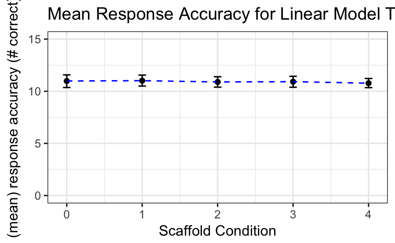

```
participantData$condition: 0
     nbr.val     nbr.null       nbr.na          min          max        range          sum       median         mean      SE.mean
  61.0000000    0.0000000    0.0000000    2.0000000   15.0000000   13.0000000  670.0000000   11.0000000   10.9836066    0.2979821
CI.mean.0.95          var      std.dev     coef.var
   0.5960530    5.4163934    2.3273146    0.2118898
--------------------------------------------------------------------------------------------------------
participantData$condition: 1
     nbr.val     nbr.null       nbr.na          min          max        range          sum       median         mean      SE.mean
  60.0000000    0.0000000    0.0000000    5.0000000   15.0000000   10.0000000  661.0000000   11.0000000   11.0166667    0.2847257
CI.mean.0.95          var      std.dev     coef.var
   0.5697349    4.8641243    2.2054760    0.2001945
--------------------------------------------------------------------------------------------------------
participantData$condition: 2
     nbr.val     nbr.null       nbr.na          min          max        range          sum       median         mean      SE.mean
  66.0000000    0.0000000    0.0000000    6.0000000   15.0000000    9.0000000  719.0000000   11.0000000   10.8939394    0.2618998
CI.mean.0.95          var      std.dev     coef.var
   0.5230500    4.5270396    2.1276841    0.1953090
--------------------------------------------------------------------------------------------------------
participantData$condition: 3
     nbr.val     nbr.null       nbr.na          min          max        range          sum       median         mean      SE.mean
  62.0000000    0.0000000    0.0000000    4.0000000   15.0000000   11.0000000  677.0000000   11.0000000   10.9193548    0.2790958
CI.mean.0.95          var      std.dev     coef.var
   0.5580865    4.8294553    2.1976022    0.2012575
--------------------------------------------------------------------------------------------------------
participantData$condition: 4
     nbr.val     nbr.null       nbr.na          min          max        range          sum       median         mean      SE.mean
  89.0000000    0.0000000    0.0000000    5.0000000   14.0000000    9.0000000  959.0000000   11.0000000   10.7752809    0.2264172
CI.mean.0.95          var      std.dev     coef.var
   0.4499567    4.5625638    2.1360159    0.1982330
```

```
participantData$condition coerced to factor.
```

```
Levene's Test for Homogeneity of Variance (center = median)
       Df F value Pr(>F)
group   4  0.1313 0.9709
      333
             Df Sum Sq Mean Sq F value Pr(>F)
condition     1    2.1   2.083   0.437  0.509
Residuals   336 1602.9   4.770
```